# Read data set

# This correlation matrix can provide insights into relationships between different variables in the dataset.

```python
vaccine_data = vaccine_backup.select_dtypes(exclude=[object])
corr_data = vaccine_data.corr()
corr_data
```

|  | Total Vaccination Doses | Dose1 | Dose 2 | Dose 1 15-18 | Dose 2 15-18 | Dose 1 12-14 | Dose 2 12-14 | Precaution 18-59 | Population |
| --- | --- | --- | --- | --- | --- | --- | --- | --- | --- |
| Total Vaccination Doses | 1.000000 | 0.995804 | 0.998924 | 0.971811 | 0.964320 | 0.977405 | 0.963909 | 0.924851 | 0.987285 |
| Dose1 | 0.995804 | 1.000000 | 0.997486 | 0.957218 | 0.944359 | 0.966013 | 0.943906 | 0.888597 | 0.987210 |
| Dose 2 | 0.998924 | 0.997486 | 1.000000 | 0.962781 | 0.953906 | 0.969957 | 0.953918 | 0.910575 | 0.987329 |
| Dose 1 15-18 | 0.971811 | 0.957218 | 0.962781 | 1.000000 | 0.997277 | 0.995244 | 0.991169 | 0.934010 | 0.959129 |
| Dose 2 15-18 | 0.964320 | 0.944359 | 0.953906 | 0.997277 | 1.000000 | 0.990573 | 0.995462 | 0.947092 | 0.946118 |
| Dose 1 12-14 | 0.977405 | 0.966013 | 0.969957 | 0.995244 | 0.990573 | 1.000000 | 0.991882 | 0.924671 | 0.968942 |
| Dose 2 12-14 | 0.963909 | 0.943906 | 0.953918 | 0.991169 | 0.995462 | 0.991882 | 1.000000 | 0.944588 | 0.946298 |
| Precaution 18-59 | 0.924851 | 0.888597 | 0.910575 | 0.934010 | 0.947092 | 0.924671 | 0.944588 | 1.000000 | 0.890697 |
| Population | 0.987285 | 0.987210 | 0.987329 | 0.959129 | 0.946118 | 0.968942 | 0.946298 | 0.890697 | 1.000000 |

# Visualizations

This code will create a scatter plot visualizing the relationship between 'Total Vaccination Doses' (on the x-axis) and 'Dose 2' (on the y-axis) in the vaccine_backup dataset. Points on the plot will be red, as specified by the c='red' parameter. The title and axis labels provide context for the plot.

[output not shown]

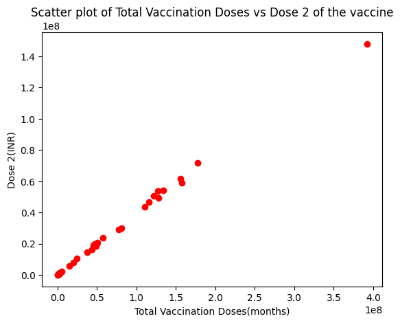

```python
plt.scatter(vaccine_backup['Total Vaccination Doses'],vaccine_backup['Dose 2'], c='red')
plt.title('Scatter plot of Total Vaccination Doses vs Dose 2 of the vaccine')
plt.xlabel('Total Vaccination Doses(months)')
plt.ylabel('Dose 2(INR)')
fig.savefig('ch.png')
```

```python
sns.set(style="darkgrid")
sns.regplot(x=vaccine_backup['Total Vaccination Doses'],y=vaccine_backup['Dose 1 12-14'],fit_reg=True, marker="*")
```

[output not shown]

This code will create an lmplot displaying 'Total Vaccination Doses' on the x-axis, 'Population' on the y-axis, with data points colored based on the values in the 'Dose 1 12-14' column. The legend will indicate the colors corresponding to each unique value in the 'Dose 1 12-14' column. No regression line will be fit to the data points due to fit_reg=False.

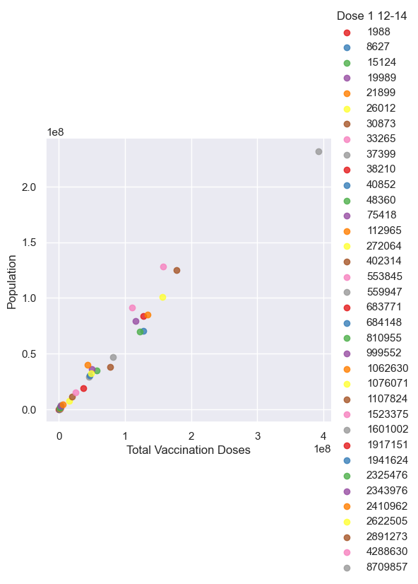

```python
sns.lmplot(x='Total Vaccination Doses',y='Population', data=vaccine_backup, fit_reg=False, hue='Dose 1 12-14', legend=True, palette='Set1')
```